# Raport z analizy danych na przedmiot **Zaawansowana Eksploracja Danych**

Michał Bartecki

11 grudzień 2015

# 1 Czytelna z GitHub’a wersja reportu

Czytelna wersja raportu (w formacie html) dostępna jest [tutaj](http://htmlpreview.github.io/?https://github.com/ireyoner/ZED/blob/master/P1_PDB_Analiza/PDB_Analiza.html).

# 2 Podsumowanie przeprowadzonej analizy

W dostarczonym zbiorze danych liczba atrybutów jest bardzo duża (ok. 800) przez co ich analiza jest bardzo utrudniona. Dodatkowym problemem jest znaczna liczba klas i rozrzut ich liczebności, który waha się od ponad 1100 dla jednej klasy do liczebności 1 dla ponad 2000 klas.

Przy takiej liczbie atrybutów nie można w prosty sposób wykonać wielu podstawowych operacji analizy danych, jak np. narysowania grafu korelacji.

Z kolei rozpatrując liczbę i niezrównoważenie ilościowe klas, problemem jest próba stworzenia klasyfikatora.

Barierą nie do obejścia podczas tej analizy był dla mnie szczególnie brak wiedzy z dziedziny z której pochodzą dane, przez co nieraz zapewne umknęły mi zapewne oczywiste (dla specjalisty z dziedziny Biologii Strukturalnej) wnioski dotyczące widocznych danych i uzyskanych wyników.

# 3 Przygotowanie do analizy

## 3.1 Wykorzystane biblioteki

Do przygotowania tej analizy zostały wykorzystane następujące biblioteki:

```r
library(knitr)
library(reshape2)
library(plyr)
library(dplyr)
# wykresy
library(ggplot2)
library(ggExtra)
library(corrplot)
library(RColorBrewer)
library(MASS)
# predykcja
library(caret)
```

## 3.2 Zapewnienie powtarzalności wyników

Zapewnienie powtarzalności wyników odbyło się poprzez wykorzystanie: [the answer to life the universe and everything](https://en.wikipedia.org/wiki/Phrases_from_The_Hitchhiker%27s_Guide_to_the_Galaxy#Answer_to_the_Ultimate_Question_of_Life.2C_the_Universe.2C_and_Everything_.2842.29)

```r
set.seed(42)
```

# 4 Wstępnie przertwarzanie danych

## 4.1 Wczytywanie danych z pliku

Wczytywanie danych z pliku zostało przyspieszone poprzez stworzenie wcześniej listy klas dla poszczególnych kolumn:

```r
classes <- rep("numeric", 795)
classes[c(1:5, 730, 731)] <- "factor"

PDB.whole.file.data <- read.table(file = "all_summary.txt", sep = ";", header = TRUE,
    comment.char = "", na.strings = c("nan", "", " "), colClasses = classes)
```

## 4.2 Wstępna filtracja danych

Ze zbioru danych usuwamy nieinteresujące nas wiersze ( według wartości zmiennej res_name). Wcześniej ten sam efekt próbowałem uzyskać wykorzystując funkcję %in%, jednak musiałem zrezygnować z jej użycia, ponieważ pojawiał się błąd o przekroczeniu limitu pamięci przy próbie wywołania funkcji.

```r
PDB.filtred.data <- PDB.whole.file.data %>% filter(res_name != "DC", res_name !=
    "DT", res_name != "DU", res_name != "DG", res_name != "DI", res_name !=
    "UNK", res_name != "UNX", res_name != "UNL", res_name != "PR", res_name !=
    "PD", res_name != "Y1", res_name != "EU", res_name != "N", res_name != "15P",
    res_name != "UQ", res_name != "PX4", res_name != "NAN", !is.na(res_name),
    !is.nan(res_name))
```

## 4.3 Pozostawienie tylko unikatowych par wartości pdb_code i res_name

```r
data.nrow.pre <- nrow(PDB.filtred.data)

PDB.filtred.data <- PDB.filtred.data %>% distinct(pdb_code, res_name)

data.nrow.post <- nrow(PDB.filtred.data)
```

Liczba wierszy przed wyczyszczeniem wynosiła 40027. Po pozostawieniu tylko unikatowych par wartości pdb_code i res_name zostało 14132 wierszy, czyli odfiltrowano 25895 wierszy.

# 5 Podstawowa analiza

## 5.1 Krótkie podsumowanie wartości w każdej kolumnie:

```r
PDB.filtred.data %>% summary() %>% kable()
```

|  | title | pdb_code | res_name | res_id | chain_id | local_BAa | local_NPa | local_Ra | local_RGa | local_SRGa | local_CCSa | local_CCPa | local_ZOa | local_ZDa | local_ZD_minus_a | local_ZD_plus_a | local_res_atom_count | local_res_atom_non_h_count | local_res_atom_non_h_occupancy_sum | local_res_atom_non_h_electron_sum | local_res_atom_non_h_electron_occupancy_sum | local_res_atom_C_count | local_res_atom_N_count | local_res_atom_O_count | local_res_atom_S_count | dict_atom_non_h_count | dict_atom_non_h_electron_sum | dict_atom_C_count | dict_atom_N_count | … |
| --- | --- | --- | --- | --- | --- | --- | --- | --- | --- | --- | --- | --- | --- | --- | --- | --- | --- | --- | --- | --- | --- | --- | --- | --- | --- | --- | --- | --- | --- | --- |
|  | 110l BME 901 A: 1 | 3ag4 : 16 | SO4 :1183 | 301 : 430 | A :8630 | Min. : NA | Min. : NA | Min. : NA | Min. : NA | Min. : NA | Min. : NA | Min. : NA | Min. : NA | Min. : NA | Min. : NA | Min. : NA | Min. : 1.00 | Min. : 1.00 | Min. : 0.00 | Min. : 3.0 | Min. : 0.00 | Min. : 0.000 | Min. : 0.00 | Min. : 0.000 | Min. :0.0000 | Min. : 1.00 | Min. : 3.0 | Min. : 0.00 | Min. : 0.000 | … |
|  | 111l CL 173 A : 1 | 3abl : 15 | ZN : 849 | 1 : 424 | B :2905 | 1st Qu.: NA | 1st Qu.: NA | 1st Qu.: NA | 1st Qu.: NA | 1st Qu.: NA | 1st Qu.: NA | 1st Qu.: NA | 1st Qu.: NA | 1st Qu.: NA | 1st Qu.: NA | 1st Qu.: NA | 1st Qu.: 1.00 | 1st Qu.: 1.00 | 1st Qu.: 1.00 | 1st Qu.: 30.0 | 1st Qu.: 30.00 | 1st Qu.: 0.000 | 1st Qu.: 0.00 | 1st Qu.: 0.000 | 1st Qu.:0.0000 | 1st Qu.: 1.00 | 1st Qu.: 30.0 | 1st Qu.: 0.00 | 1st Qu.: 0.000 | … |
|  | 115l BME 901 A: 1 | 3abk : 14 | GOL : 778 | 501 : 417 | C : 795 | Median : NA | Median : NA | Median : NA | Median : NA | Median : NA | Median : NA | Median : NA | Median : NA | Median : NA | Median : NA | Median : NA | Median : 7.00 | Median : 7.00 | Median : 7.00 | Median : 55.0 | Median : 52.00 | Median : 3.000 | Median : 0.00 | Median : 3.000 | Median :0.0000 | Median : 7.00 | Median : 56.0 | Median : 3.00 | Median : 0.000 | … |
|  | 115l CL 173 A : 1 | 2afh : 11 | CA : 661 | 401 : 395 | D : 552 | Mean :NaN | Mean :NaN | Mean :NaN | Mean :NaN | Mean :NaN | Mean :NaN | Mean :NaN | Mean :NaN | Mean :NaN | Mean :NaN | Mean :NaN | Mean : 13.59 | Mean : 13.43 | Mean : 13.05 | Mean :101.5 | Mean : 98.33 | Mean : 7.332 | Mean : 1.35 | Mean : 3.817 | Mean :0.2208 | Mean : 13.74 | Mean :103.8 | Mean : 7.47 | Mean : 1.357 | … |
|  | 123l BME 901 A: 1 | 3a0b : 11 | MG : 402 | 201 : 306 | E : 221 | 3rd Qu.: NA | 3rd Qu.: NA | 3rd Qu.: NA | 3rd Qu.: NA | 3rd Qu.: NA | 3rd Qu.: NA | 3rd Qu.: NA | 3rd Qu.: NA | 3rd Qu.: NA | 3rd Qu.: NA | 3rd Qu.: NA | 3rd Qu.: 21.00 | 3rd Qu.: 20.00 | 3rd Qu.: 20.00 | 3rd Qu.:145.0 | 3rd Qu.:139.15 | 3rd Qu.:10.000 | 3rd Qu.: 2.00 | 3rd Qu.: 5.000 | 3rd Qu.:0.0000 | 3rd Qu.: 21.00 | 3rd Qu.:151.0 | 3rd Qu.:10.00 | 3rd Qu.: 2.000 | … |
|  | 123l CL 173 A : 1 | 3g6e : 11 | CL : 400 | 500 : 228 | H : 153 | Max. : NA | Max. : NA | Max. : NA | Max. : NA | Max. : NA | Max. : NA | Max. : NA | Max. : NA | Max. : NA | Max. : NA | Max. : NA | Max. :178.00 | Max. :104.00 | Max. :104.00 | Max. :800.0 | Max. :800.00 | Max. :81.000 | Max. :15.00 | Max. :55.000 | Max. :9.0000 | Max. :128.00 | Max. :866.0 | Max. :81.00 | Max. :20.000 | … |
|  | (Other) :14126 | (Other):14054 | (Other):9859 | (Other):11932 | (Other): 876 | NA’s :14132 | NA’s :14132 | NA’s :14132 | NA’s :14132 | NA’s :14132 | NA’s :14132 | NA’s :14132 | NA’s :14132 | NA’s :14132 | NA’s :14132 | NA’s :14132 | NA | NA | NA | NA | NA | NA | NA | NA | NA | NA’s :19 | NA’s :19 | NA’s :19 | NA’s :19 | … |

## 5.2 Dodatkowa filtracja danych

Na podstawie powyższej tabeli można zauważyć, że kolumny:

- local_BAa
- local_NPa
- local_Ra
- local_RGa
- local_SRGa
- local_CCSa
- local_CCPa
- local_ZOa
- local_ZDa
- local_ZD_minus_a
- local_ZD_plus_a
- local_min
- fo_col
- fc_col
- weight_col
- grid_space
- solvent_radius
- solvent_opening_radius
- resolution_max_limit
- part_step_FoFc_std_min
- part_step_FoFc_std_max
- part_step_FoFc_std_step

nie wnoszą żadnej informacji do zboru danych, ponieważ albo są puste, albo zawierają identyczne wartości we wszystkich wierszach, więc zostaną usunięte z dalszego przetwarzania.

Dodatkowo z dalszego przetwarzania zostaną usunięte kolumny res_id i chain_id -

```r
PDB.filtred.data <- PDB.filtred.data %>% dplyr::select(-c(local_BAa, local_NPa,
    local_Ra, local_RGa, local_SRGa, local_CCSa, local_CCPa, local_ZOa, local_ZDa,
    local_ZD_minus_a, local_ZD_plus_a, local_min, fo_col, fc_col, weight_col,
    grid_space, solvent_radius, solvent_opening_radius, resolution_max_limit,
    part_step_FoFc_std_min, part_step_FoFc_std_max, part_step_FoFc_std_step,
    res_id, chain_id))
```

## 5.3 Korelacja parametrów

Do pomocy w przeprowadzeniu obliczeń korelacji parametrów posłużą nam następujące funkcje pomocnicze:

```r
count.cor.summary <- function(data, cols.name, func, ...) {
    plot.data <- data %>% dplyr::select(starts_with(paste0(cols.name, "_part_")))
    if (dim(plot.data)[2] > 1) {
        plot.data <- cor(plot.data, use = "pairwise.complete.obs")
        diag(plot.data) <- NA
        return(func(plot.data, na.rm = TRUE))
    } else {
        return(NA)
    }
}

make.corrplot <- function(data, order, ...) {
    plot.data <- data
    if (dim(plot.data)[2] > 1) {
        plot.data <- cor(plot.data, use = "pairwise.complete.obs")
        plot.data[is.na(plot.data)] <- 0
        corrplot(plot.data, order = order, method = "color", tl.pos = "d", type = "upper",
            tl.cex = 0.6, tl.col = "black", addCoefasPercent = FALSE, pos = 2,
            cl.pos = "n")
    }
}
```

Ponieważ w danych znajduje się wiele kolumn (69 atrybutów dla 10 ligandów) dotyczących poszczególnych ligandów, wyliczymy maksymalną, średnią i maksymalną korelację dla każdego zestawu atrybutów między ligandami. W tym celu zmienimy chwilowo nazwy kolumn w zbiorze danych, tak żeby opis, z którego ligandu (partu) pochodzą, znalazł się na końcu ich nazwy.

```r
# rename, tak żeby part_xx było na końcu nazwy:
part_xx_cor_data <- PDB.filtred.data %>% dplyr::select(starts_with("part_")) %>%
    dplyr::select(which(sapply(., is.numeric)))

colnames(part_xx_cor_data) <- paste0(substring(colnames(part_xx_cor_data), 9),
    "_", substring(colnames(part_xx_cor_data), 1, 7))

part_col_names <- PDB.filtred.data %>% dplyr::select(starts_with("part_00")) %>%
    dplyr::select(which(sapply(., is.numeric))) %>% colnames(.) %>% substring(.,
    9)

part_col_cor_means <- data.frame(part_col_names = part_col_names, max = sapply(part_col_names,
    count.cor.summary, data = part_xx_cor_data, func = max), mean = sapply(part_col_names,
    count.cor.summary, data = part_xx_cor_data, func = mean), min = sapply(part_col_names,
    count.cor.summary, data = part_xx_cor_data, func = min))

part_col_cor_means <- part_col_cor_means %>% arrange(desc(mean), desc(max),
    desc(min)) %>% t()
```

Dane w poniższej tabeli są posortowane malejąco według średniej korelacji danego atrybutu.

```r
part_col_cor_means[2:4, ] %>% kable(col.names = part_col_cor_means[1, ])
```

|  | shape_O5 | shape_I2 | shape_O4 | shape_FL | density_O5 | density_I2 | shape_I4 | shape_I5 | shape_I6 | shape_I3 | shape_I1 | shape_O3 | blob_volume_sum | shape_M000 | density_O4 | blob_electron_sum | density_M000 | density_FL | density_E3_E1 | shape_E3_E1 | density_O3 | density_sqrt_E1 | density_I1 | density_I4 | shape_sqrt_E1 | density_I5 | density_E3_E2 | density_E2_E1 | density_I6 | … |
| --- | --- | --- | --- | --- | --- | --- | --- | --- | --- | --- | --- | --- | --- | --- | --- | --- | --- | --- | --- | --- | --- | --- | --- | --- | --- | --- | --- | --- | --- | --- |
| max | 0.9999846 | 0.9999398 | 0.9995329 | 0.9990439 | 0.9994260 | 0.9990957 | 0.9983139 | 0.9995988 | 0.9981487 | 0.9982936 | 0.9991801 | 0.9990933 | 0.9985158 | 0.9989020 | 0.9989254 | 0.9987628 | 0.9993177 | 0.9972505 | 0.9873671 | 0.9844549 | 0.9992835 | 0.9961865 | 0.9991103 | 0.9980834 | 0.9957850 | 0.9992662 | 0.9796477 | 0.9757936 | 0.9978123 | … |
| mean | 0.9980580 | 0.9947573 | 0.9794083 | 0.9730417 | 0.9684745 | 0.9664357 | 0.9592465 | 0.9241444 | 0.9118193 | 0.9058747 | 0.9045451 | 0.8913706 | 0.8909287 | 0.8871500 | 0.8812005 | 0.8738777 | 0.8691475 | 0.8570007 | 0.8527239 | 0.8435887 | 0.8326143 | 0.8164325 | 0.8144415 | 0.8135023 | 0.8096409 | 0.7748233 | 0.7652647 | 0.7651312 | 0.7641449 | … |
| min | 0.991853921 | 0.971523061 | 0.925452870 | 0.904664172 | 0.920741966 | 0.879963708 | 0.887067564 | 0.721366928 | 0.757493952 | 0.622819235 | 0.758687334 | 0.705872642 | 0.663013554 | 0.660624040 | 0.687417089 | 0.629594729 | 0.609854239 | 0.690566134 | 0.686333884 | 0.662183771 | 0.548845638 | 0.618078707 | 0.577942956 | 0.534323522 | 0.605425878 | 0.381645237 | 0.516840565 | 0.580079283 | 0.509392254 | … |

Na podstawie powyższej tabeli widzimy, że wszystkie atrybuty poszczególnych ligandów są ze sobą skorelowane pozytywnie, ale w różnym stopniu. Poniżej przedstawione są graficznie korelacje dla pierwszego, środkowego i ostatniego atrybutu pod względem korelacji.

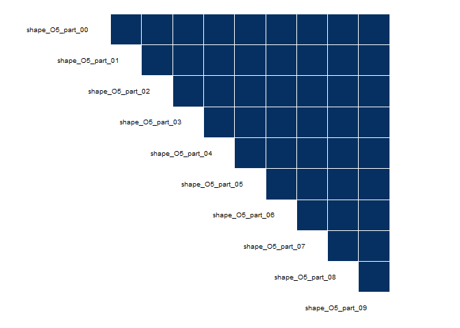

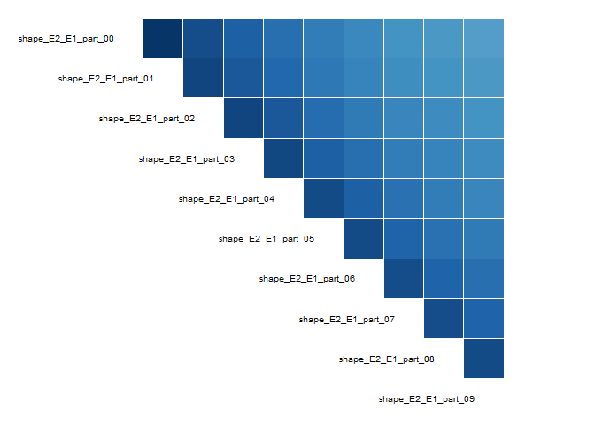

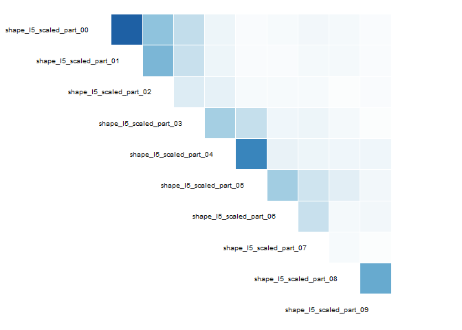

```r
cat.corr.table <- function() {
    cat("<table border=\"0\" width=\"2022\">")
    cat("<tr>")
    cat("<td>")
    part_xx_cor_data %>% dplyr::select(starts_with(paste0(part_col_cor_means[1,
        1], "_part_"))) %>% make.corrplot(order = "alphabet")
    cat("</td>")
    cat("<td>")
    part_xx_cor_data %>% dplyr::select(starts_with(paste0(part_col_cor_means[1,
        35], "_part_"))) %>% make.corrplot(order = "alphabet")
    cat("</td>")
    cat("<td>")
    part_xx_cor_data %>% dplyr::select(starts_with(paste0(part_col_cor_means[1,
        69], "_part_"))) %>% make.corrplot(order = "alphabet")
    cat("</td>")
    cat("</tr>")
    cat("</table>")
}
cat.corr.table()
```

Warto obejrzeć też korelację dla wszystkich atrybutów opisujących ligand. Poniżej przedstawiona jest graficznie korelacja atrybutów dla pierwszego z ligandów (part_00) opisanych w dostarczonych danych. Wykres ten byłby bardzo podobny dla każdego ligandu, ponieważ poszczególne atrybuty dla są skorelowane między ligandami.

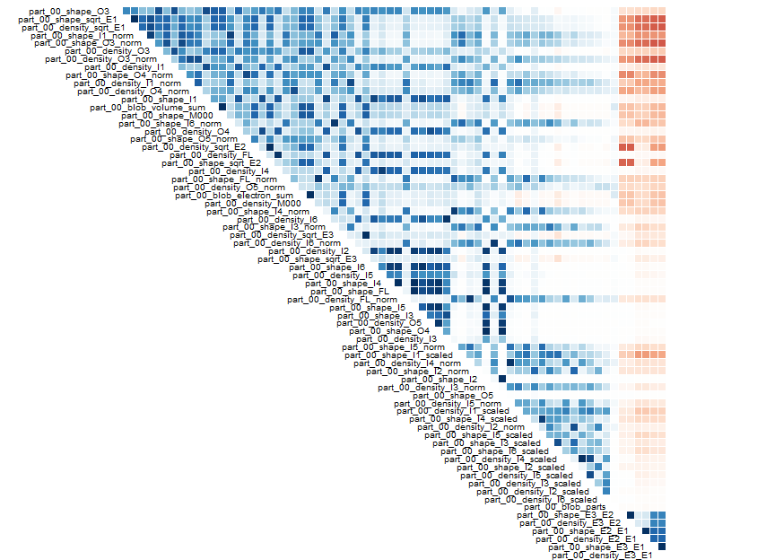

```r
PDB.filtred.data %>% dplyr::select(starts_with("part_00_")) %>% dplyr::select(which(sapply(.,
    is.numeric))) %>% make.corrplot(order = "FPC")
```

Jak widać, nie wszystkie atrybuty dotyczące ligandu są między sobą skorelowane, szczególnie odstają od siebie dane dotyczące kształtu i gęstości ligandu.

Dodatkowo w danych znalazły się inne numeryczne atrybuty, dla których można wyliczyć korelację. Poniżej przedstawione są jej wyniki:

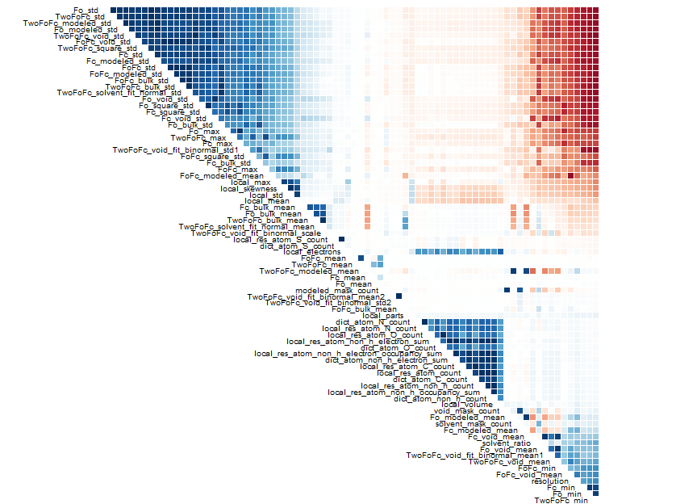

```r
cor_data <- PDB.filtred.data %>% dplyr::select(-starts_with("part_")) %>% dplyr::select(which(sapply(.,
    is.numeric))) %>% make.corrplot(order = "FPC")
```

## 5.4 Określenie liczności klas

Określenie ile przykładów ma każda z klas (res_name). Dane w poniższej tabeli zostały posortowane malejąco według liczności klasy.

```r
res.names.counts <- PDB.filtred.data %>% group_by(res_name) %>% summarise(liczba = n()) %>%
    arrange(desc(liczba), res_name)
n <- res.names.counts$res_name
res.names.counts.row <- as.data.frame(t(res.names.counts[, -1]))
colnames(res.names.counts.row) <- n
rownames(res.names.counts.row) <- NULL

res.names.counts.row %>% kable()
```

| SO4 | ZN | GOL | CA | MG | CL | NAG | PO4 | HEM | EDO | NA | MN | ACT | FAD | ADP | FE | K | ATP | CU | PEG | NAP | CD | NAD | MES | NI | FMN | EPE | BME | PG4 | TRS | … |
| --- | --- | --- | --- | --- | --- | --- | --- | --- | --- | --- | --- | --- | --- | --- | --- | --- | --- | --- | --- | --- | --- | --- | --- | --- | --- | --- | --- | --- | --- | --- |
| 1183 | 849 | 778 | 661 | 402 | 400 | 396 | 301 | 296 | 274 | 238 | 182 | 167 | 157 | 138 | 120 | 119 | 106 | 104 | 90 | 86 | 81 | 80 | 79 | 76 | 73 | 72 | 67 | 67 | 63 | … |

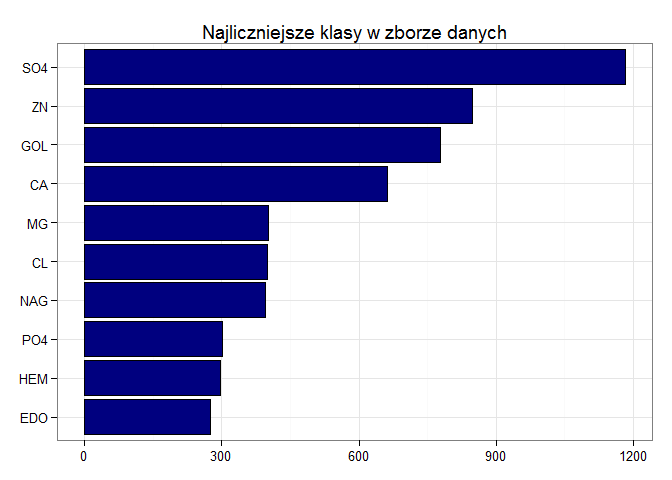

```r
res.names.counts.head <- res.names.counts %>% head(10)
res.names.counts.head$res_name <- reorder(res.names.counts.head$res_name, res.names.counts.head$liczba)

res.names.counts.head %>% ggplot(aes(res_name, liczba, order = as.numeric(liczba))) +
    geom_bar(stat = "identity", show_guide = FALSE, fill = "#00007F", colour = "black") +
    coord_flip() + ggtitle("Najliczniejsze klasy w zborze danych") + theme_bw() +
    theme(axis.title.x = element_blank(), axis.title.y = element_blank(), legend.position = "none")
```

## 5.5 Rozkłady liczby atomów i elektronów

Na wykresach w osi Y zastosowana została skala kwadratowa, ponieważ niektóre wartości prezentowane na wykresach są tak małe, że przy użyciu skali liniowej nie były widoczne.

Wykres rozkładu liczby atomów (local_res_atom_non_h_count):

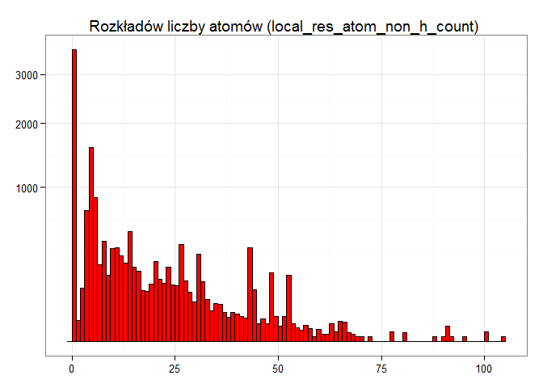

```r
ggplot(PDB.filtred.data, aes(x = local_res_atom_non_h_count)) + geom_histogram(binwidth = max((max(PDB.filtred.data$local_res_atom_non_h_count)/100),
    1), colour = "black", fill = "red") + scale_y_sqrt() + ggtitle("Rozkładów liczby atomów (local_res_atom_non_h_count) ") +
    theme_bw() + theme(axis.title.x = element_blank(), axis.title.y = element_blank(),
    legend.position = "none")
```

Wykres rozkładu liczby elektronów (local_res_atom_non_h_electron_sum):

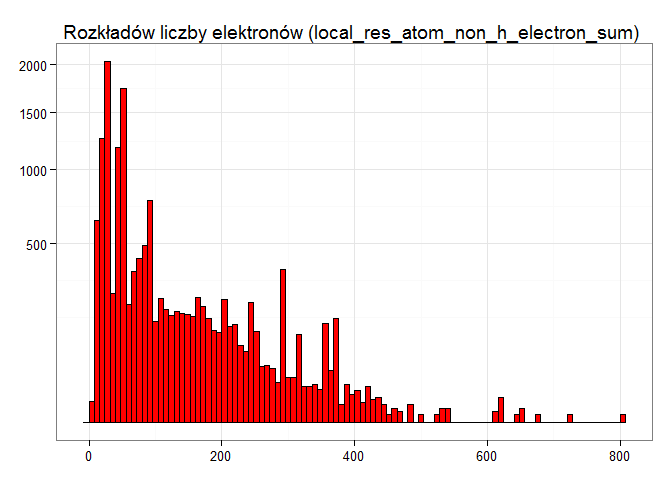

```r
ggplot(PDB.filtred.data, aes(x = local_res_atom_non_h_electron_sum)) + geom_histogram(binwidth = max((max(PDB.filtred.data$local_res_atom_non_h_electron_sum)/100),
    1), colour = "black", fill = "red") + scale_y_sqrt() + ggtitle("Rozkładów liczby elektronów (local_res_atom_non_h_electron_sum) ") +
    theme_bw() + theme(axis.title.x = element_blank(), axis.title.y = element_blank(),
    legend.position = "none")
```

Na powyższych wykresach widać duże niezrównoważenie liczby atomów i elektronów w analizowanej próbce danych. Szczególnie liczne są cząsteczki składające się tylko 1 atomu, natomiast cząsteczek o liczbie atomów powyżej 50, lub liczbie elektronów powyżej 400 prawie nie ma.

# 6 Zaawansowana analiza

## 6.1 Próba odtorzenia wykresu prowadzącego

Poniżej widoczne są wyniki próby odtworzenia wykresu prowadzącego zajęcia. Jest to alternatywny (i lepszy) sposób przedstawienia powyższych wykresów.

Podjęto wiele prób dopasowania go do oryginału, który można obejrzeć na [tej stronie](http://www.cs.put.poznan.pl/dbrzezinski/teaching/zed/zed_projekt_2015-2016_analiza.html).

Ostatecznie zastosowano dwa różne podejścia:

- Pierwsze oparte o wykorzystanie bibliotek [ggplot2](http://docs.ggplot2.org/current/) i [ggExtra](https://cran.r-project.org/web/packages/ggExtra/vignettes/overview.html)
- Drugie wykorzystuje metodę opisaną na bibliotece [MASS](https://cran.r-project.org/web/packages/MASS/MASS.pdf) opisaną na stronie [r-bloggers.com: 5-ways-to-do-2d-histograms-in-r](http://www.r-bloggers.com/5-ways-to-do-2d-histograms-in-r/)

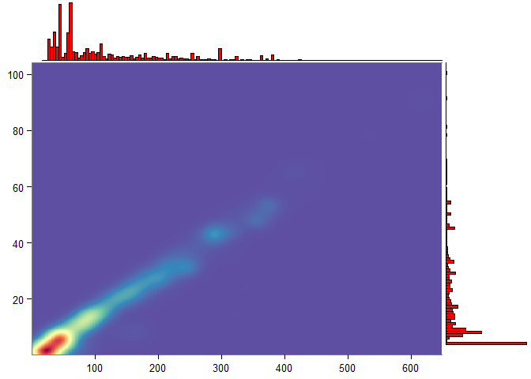

```r
plot.data <- PDB.filtred.data %>% dplyr::select(local_res_atom_non_h_electron_sum,
    local_res_atom_non_h_count) %>% filter(local_res_atom_non_h_electron_sum <=
    700)

p <- ggplot(plot.data, aes(x = local_res_atom_non_h_electron_sum, y = local_res_atom_non_h_count)) +
    stat_density2d(geom = "tile", aes(fill = ..density..), contour = FALSE,
        na.rm = TRUE, n = c(400)) + scale_fill_gradientn(colours = rev(brewer.pal(11,
    "Spectral"))) + scale_x_continuous(expand = c(0, 0), breaks = seq(100, 600,
    by = 100), limits = c(0, 650)) + scale_y_continuous(expand = c(0, 0), breaks = seq(20,
    100, by = 20), limits = c(0, max(plot.data$local_res_atom_non_h_count))) +
    theme_bw() + theme(axis.title.x = element_blank(), axis.title.y = element_blank(),
    legend.position = "none")

ggExtra::ggMarginal(p, type = "histogram", colour = "black", fill = "red", xparams = list(binwidth = max((max(plot.data$local_res_atom_non_h_electron_sum)/150),
    1)), yparams = list(binwidth = max((max(plot.data$local_res_atom_non_h_count)/100),
    1)))
```

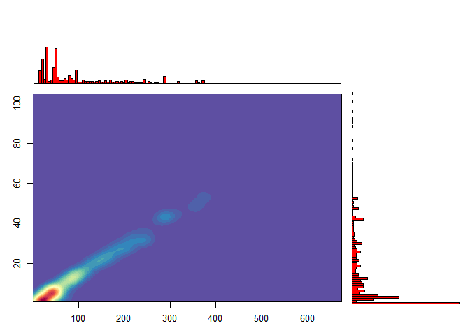

```r
# Adjust binning (interpolate - can be computationally intensive for large
# datasets)
h1 <- hist(plot.data$local_res_atom_non_h_electron_sum, breaks = 150, plot = F)
h2 <- hist(plot.data$local_res_atom_non_h_count, breaks = 100, plot = F)
top <- max(h1$counts, h2$counts)
k <- kde2d(plot.data$local_res_atom_non_h_electron_sum, plot.data$local_res_atom_non_h_count,
    n = 400)

# margins
oldpar <- par()
par(mar = c(3, 3, 1, 1))
layout(matrix(c(2, 0, 1, 3), 2, 2, byrow = T), c(3, 1), c(1, 3))
image(k, col = colorRampPalette(rev(brewer.pal(11, "Spectral")))(32))  #plot the image
par(mar = c(0, 2, 1, 0))
barplot(h1$counts, axes = F, ylim = c(0, top), space = 0, col = "red")
par(mar = c(2, 0, 0, 1))
barplot(h2$counts, axes = F, xlim = c(0, top), space = 0, col = "red", horiz = T)
```

## 6.2 Niezgodność liczby atomów i elektronów

Zarówno dla elektronów i dla atomów liczby słownikowe są identyczne dla każdej instancji klasy i dlatego możemy pozwolić na pobranie tych danych przy wykorzystaniu funkcji first().

Poniżej przedstawiona jest tabela 10 klas z największą niezgodnością liczby atomów (local_res_atom_non_h_count vs dict_atom_non_h_count):

```r
PDB.filtred.data %>% dplyr::select(res_name, local = local_res_atom_non_h_count,
    dict = dict_atom_non_h_count) %>% group_by(res_name) %>% summarise(count = n(),
    dict = first(dict), min_local = min(local), avg_local = round(mean(local),
        2), max_local = max(local), min_diff = min(abs(local - dict)), avg_diff = round(mean(abs(local -
        dict)), 2), max_diff = max(abs(local - dict)), niezgodnosc = max_diff -
        min_diff) %>% arrange(desc(niezgodnosc), res_name) %>% head(10) %>%
    kable()
```

| res_name | count | dict | min_local | avg_local | max_local | min_diff | avg_diff | max_diff | niezgodnosc |
| --- | --- | --- | --- | --- | --- | --- | --- | --- | --- |
| CDL | 9 | 100 | 40 | 75.22 | 100 | 0 | 24.78 | 60 | 60 |
| 3TL | 3 | 66 | 33 | 55.00 | 66 | 0 | 11.00 | 33 | 33 |
| PE3 | 2 | 43 | 10 | 26.50 | 43 | 0 | 16.50 | 33 | 33 |
| B4P | 3 | 53 | 22 | 42.67 | 53 | 0 | 10.33 | 31 | 31 |
| PEE | 4 | 51 | 18 | 35.00 | 49 | 2 | 16.00 | 33 | 31 |
| PC1 | 3 | 54 | 11 | 20.67 | 39 | 15 | 33.33 | 43 | 28 |
| LMT | 16 | 35 | 9 | 28.38 | 35 | 0 | 6.62 | 26 | 26 |
| PLC | 4 | 42 | 12 | 25.50 | 34 | 8 | 16.50 | 30 | 22 |
| COA | 35 | 48 | 27 | 46.66 | 48 | 0 | 1.34 | 21 | 21 |
| GTP | 37 | 32 | 13 | 31.27 | 32 | 0 | 0.73 | 19 | 19 |

Poniżej przedstawiona jest tabela 10 klas z największą niezgodnością liczby atomów (local_res_atom_non_h_electron_sum vs dict_atom_non_h_electron_sum):

```r
PDB.filtred.data %>% dplyr::select(res_name, local = local_res_atom_non_h_electron_sum,
    dict = dict_atom_non_h_electron_sum) %>% group_by(res_name) %>% summarise(count = n(),
    dict = first(dict), min_local = min(local), avg_local = round(mean(local),
        2), max_local = max(local), min_diff = min(abs(local - dict)), avg_diff = round(mean(abs(local -
        dict)), 2), max_diff = max(abs(local - dict)), niezgodnosc = max_diff -
        min_diff) %>% arrange(desc(niezgodnosc), res_name) %>% head(10) %>%
    kable()
```

| res_name | count | dict | min_local | avg_local | max_local | min_diff | avg_diff | max_diff | niezgodnosc |
| --- | --- | --- | --- | --- | --- | --- | --- | --- | --- |
| CDL | 9 | 652 | 292 | 503.11 | 652 | 0 | 148.89 | 360 | 360 |
| PE3 | 2 | 288 | 66 | 177.00 | 288 | 0 | 111.00 | 222 | 222 |
| B4P | 3 | 402 | 182 | 328.67 | 402 | 0 | 73.33 | 220 | 220 |
| PEE | 4 | 332 | 108 | 223.00 | 320 | 12 | 109.00 | 224 | 212 |
| 3TL | 3 | 422 | 211 | 351.67 | 422 | 0 | 70.33 | 211 | 211 |
| PC1 | 3 | 350 | 66 | 138.33 | 259 | 91 | 211.67 | 284 | 193 |
| LMT | 16 | 232 | 54 | 188.12 | 232 | 0 | 43.88 | 178 | 178 |
| COA | 35 | 364 | 205 | 354.09 | 364 | 0 | 9.91 | 159 | 159 |
| PLC | 4 | 278 | 90 | 170.50 | 230 | 48 | 107.50 | 188 | 140 |
| GTP | 37 | 252 | 125 | 246.46 | 252 | 0 | 5.54 | 127 | 127 |

Jak widać w powyższych tabelach dla wszystkich przedstawionych ligandów, uzyskane wyniki zawsze nigdy nie przekroczyły wartości opisanych w słownikach.

## 6.3 Rozkład wartości atrybutów zaczynających się od part_01

Poniżej przedstawiony jest rozkład wartości wszystkich atrybutów zaczynających się od part_01. Na wykresach przerywaną ciemnoniebieską linią zaznaczona jest średnia wartość, a liczbowa wartość tej średniej znajduje się pod tytułem wykresu.

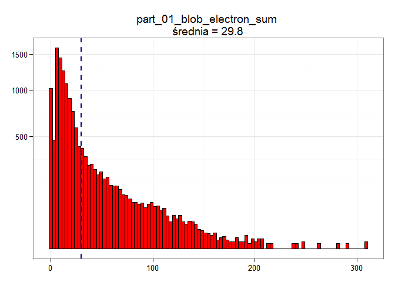

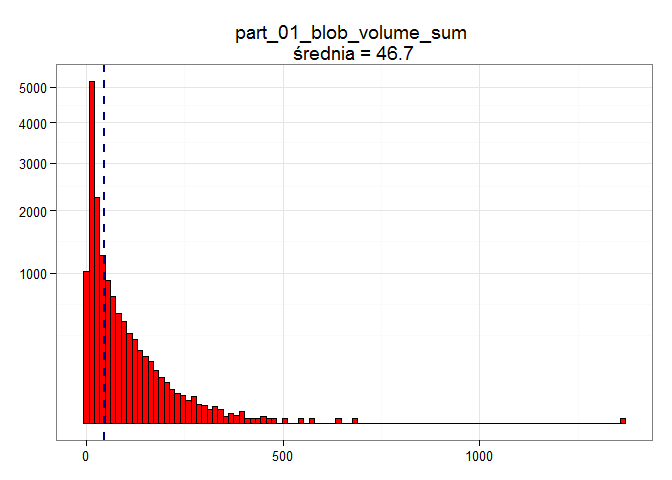

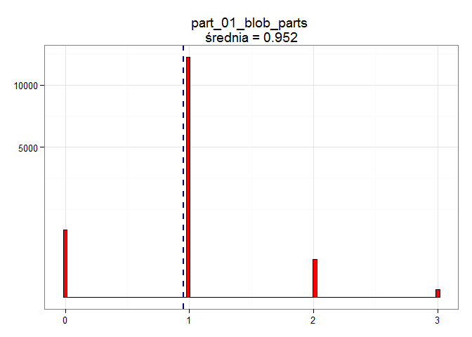

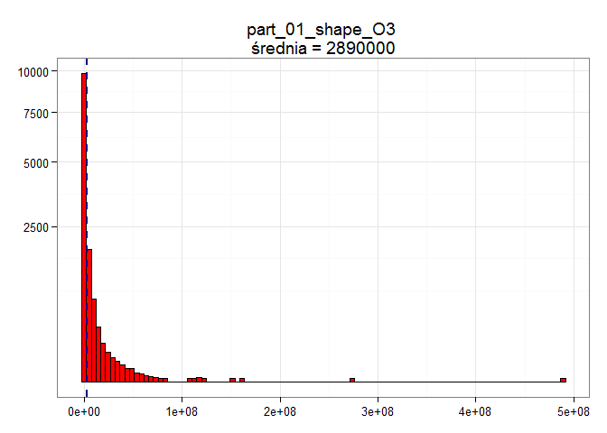

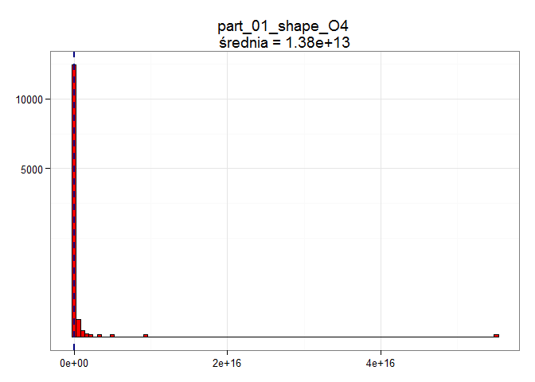

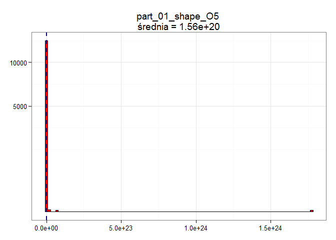

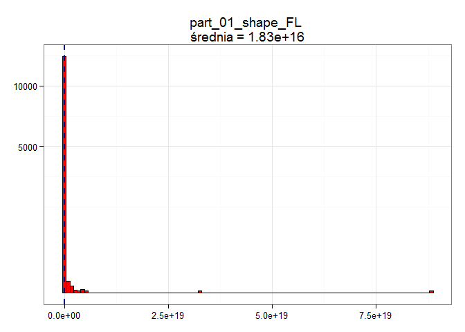

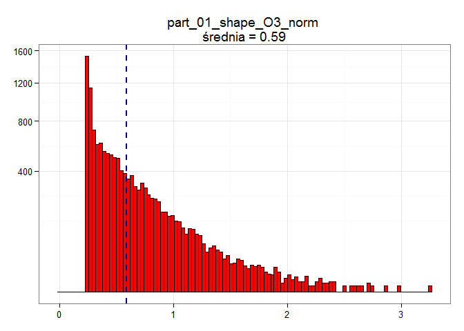

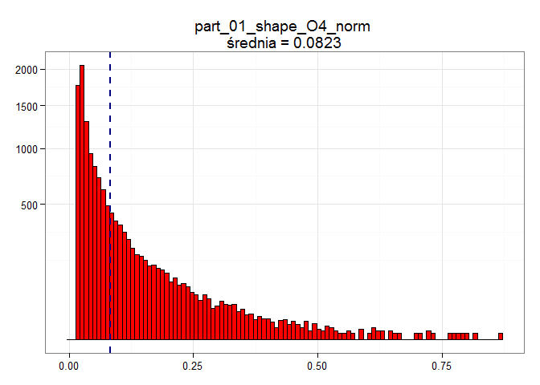

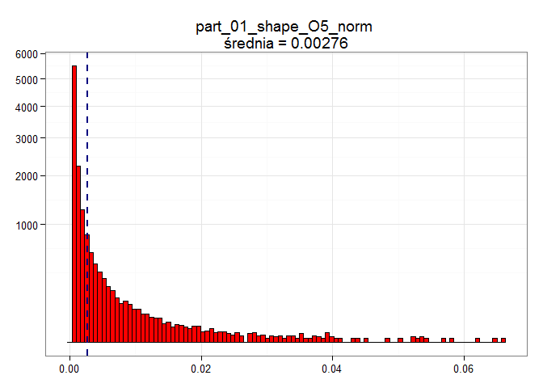

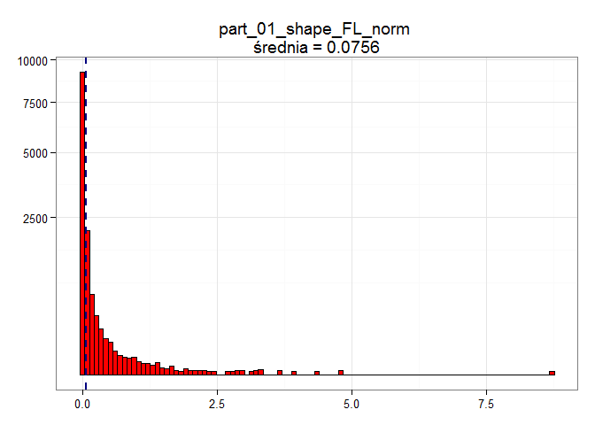

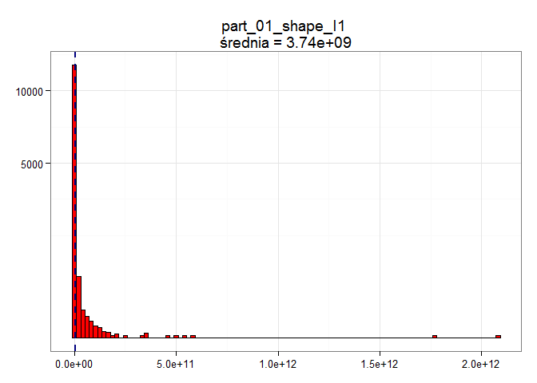

[57 more figures not shown]

```r
PDB.part_01.data <- PDB.filtred.data %>% dplyr::select(starts_with("part_01"))

cat.part_01_items.table <- function() {
    cat(paste0("<table border=\"0\" width=\"", dim(PDB.part_01.data)[2] * 764,
        "\">"))
    cat("<tr>")
    for (i in 1:dim(PDB.part_01.data)[2]) {
        PDB.part_01.col.data <<- PDB.part_01.data[, i] %>% melt

        PDB.part_01.col.data.mean <<- mean(PDB.part_01.col.data$value, na.rm = TRUE)
        PDB.part_01.col.data.binwidth <<- max((max(PDB.part_01.col.data$value,
            na.rm = TRUE) - min(PDB.part_01.col.data$value, na.rm = TRUE))/100)
        PDB.part_01.col.data.title <<- paste(colnames(PDB.part_01.data[i]),
            "\nśrednia =", signif(PDB.part_01.col.data.mean, 3))

        p <- ggplot(PDB.part_01.col.data, aes(x = value)) + geom_histogram(binwidth = PDB.part_01.col.data.binwidth,
            origin = (-0.5 * PDB.part_01.col.data.binwidth), colour = "black",
            fill = "red") + geom_vline(mapping = aes(xintercept = PDB.part_01.col.data.mean),
            linetype = "dashed", colour = "#00007F", size = 1) + theme_bw() +
            scale_y_sqrt() + theme(legend.position = "none") + ggtitle(PDB.part_01.col.data.title) +
            theme(axis.title.x = element_blank(), axis.title.y = element_blank(),
                legend.position = "none")

        cat("<td>")
        print(p)
        cat("</td>")
    }
    cat("</tr>")
    cat("</table>")
}
cat.part_01_items.table()
```

Z wykresów widać, że wiele atrybutów ma nieliniowy rozkład wartości, przez co wykresy z liniową skalą wartości x niezbyt dobrze wizualizują zmienność danego atrybutu.

## 6.4 Miary R^2 i RMSE

Poniżej przedstawione są atrybuty o najlepszych wartościach miar R^2 i RMSE dla liczby atomów (local_res_atom_non_h_count).

```r
# pobranie kolumn tylko numerycznych
r2.and.rmse.filtred.data <- PDB.filtred.data %>% dplyr::select(which(sapply(.,
    is.numeric)))

# wyliczenie miar R2 dla local_res_atom_non_h_count
atom.R2 <- r2.and.rmse.filtred.data %>% dplyr::select(-local_res_atom_non_h_count) %>%
    sapply(function(x) {
        mylm <- lm(x ~ r2.and.rmse.filtred.data$local_res_atom_non_h_count)
        theR2 <- summary(mylm)$r.squared
        return(theR2)
    }) %>% (function(x) {
    return(x[order(x, decreasing = TRUE, na.last = TRUE)])
}) %>% head(10)

# wyliczenie miar RMSE dla local_res_atom_non_h_count
atom.RMSE <- r2.and.rmse.filtred.data %>% dplyr::select(-local_res_atom_non_h_count) %>%
    sapply(function(x) {
        theRMSE <- sqrt(mean((x - r2.and.rmse.filtred.data$local_res_atom_non_h_count)^2,
            na.rm = TRUE))
        return(theRMSE)
    }) %>% (function(x) {
    return(x[order(x, decreasing = FALSE, na.last = FALSE)])
}) %>% head(10)

# wyświetlenie wartości dla local_res_atom_non_h_count
data.frame(`R2 Column Name` = names(atom.R2), `R2 Value` = atom.R2, `RMSE Column Name` = names(atom.RMSE),
    `RMSE Value` = atom.RMSE, row.names = NULL) %>% kable()
```

| R2.Column.Name | R2.Value | RMSE.Column.Name | RMSE.Value |
| --- | --- | --- | --- |
| local_res_atom_count | 0.9859716 | local_res_atom_count | 1.747344 |
| dict_atom_non_h_count | 0.9798389 | local_res_atom_non_h_occupancy_sum | 2.096687 |
| local_res_atom_non_h_occupancy_sum | 0.9795675 | dict_atom_non_h_count | 2.122247 |
| local_res_atom_non_h_electron_sum | 0.9702928 | local_res_atom_C_count | 8.737087 |
| dict_atom_non_h_electron_sum | 0.9545624 | dict_atom_C_count | 8.743930 |
| local_res_atom_non_h_electron_occupancy_sum | 0.9515772 | part_00_shape_sqrt_E1 | 11.072554 |
| local_res_atom_C_count | 0.8796270 | part_00_density_sqrt_E1 | 11.214142 |
| dict_atom_C_count | 0.8540416 | part_01_shape_sqrt_E1 | 11.322407 |
| local_res_atom_N_count | 0.6447335 | part_01_density_sqrt_E1 | 11.470557 |
| dict_atom_N_count | 0.6432418 | part_02_shape_sqrt_E1 | 12.020760 |

```r
# wyliczenie miar R2 dla local_res_atom_non_h_electron_sum
electron.R2 <- r2.and.rmse.filtred.data %>% dplyr::select(-local_res_atom_non_h_electron_sum) %>%
    sapply(function(x) {
        mylm <- lm(x ~ r2.and.rmse.filtred.data$local_res_atom_non_h_electron_sum)
        theR2 <- summary(mylm)$r.squared
        return(theR2)
    }) %>% (function(x) {
    return(x[order(x, decreasing = TRUE, na.last = TRUE)])
}) %>% head(10)

# wyliczenie miar RMSE dla local_res_atom_non_h_electron_sum
electron.RMSE <- r2.and.rmse.filtred.data %>% dplyr::select(-local_res_atom_non_h_electron_sum) %>%
    sapply(function(x) {
        theRMSE <- sqrt(mean((x - r2.and.rmse.filtred.data$local_res_atom_non_h_electron_sum)^2,
            na.rm = TRUE))
        return(theRMSE)
    }) %>% (function(x) {
    return(x[order(x, decreasing = FALSE, na.last = FALSE)])
}) %>% head(10)

# wyświetlenie wartości dla local_res_atom_non_h_electron_sum
data.frame(`R2 Column Name` = names(atom.R2), `R2 Value` = atom.R2, `RMSE Column Name` = names(atom.RMSE),
    `RMSE Value` = atom.RMSE, row.names = NULL) %>% kable()
```

| R2.Column.Name | R2.Value | RMSE.Column.Name | RMSE.Value |
| --- | --- | --- | --- |
| local_res_atom_count | 0.9859716 | local_res_atom_count | 1.747344 |
| dict_atom_non_h_count | 0.9798389 | local_res_atom_non_h_occupancy_sum | 2.096687 |
| local_res_atom_non_h_occupancy_sum | 0.9795675 | dict_atom_non_h_count | 2.122247 |
| local_res_atom_non_h_electron_sum | 0.9702928 | local_res_atom_C_count | 8.737087 |
| dict_atom_non_h_electron_sum | 0.9545624 | dict_atom_C_count | 8.743930 |
| local_res_atom_non_h_electron_occupancy_sum | 0.9515772 | part_00_shape_sqrt_E1 | 11.072554 |
| local_res_atom_C_count | 0.8796270 | part_00_density_sqrt_E1 | 11.214142 |
| dict_atom_C_count | 0.8540416 | part_01_shape_sqrt_E1 | 11.322407 |
| local_res_atom_N_count | 0.6447335 | part_01_density_sqrt_E1 | 11.470557 |
| dict_atom_N_count | 0.6432418 | part_02_shape_sqrt_E1 | 12.020760 |

Można zauważyć, że część atrybutów posiada zarówno dobrą miarę R^2 i RMSE, jednak są to wartości słownikowe lub zmienne modelowania, które nie będą znane w trakcie przeprowadzania predykcji. Pocieszający jest fakt, że dla miary RMSE widać atrybuty zaczynające się od part_xx, ponieważ to na nich oparty będzie głównie proces klasyfikacji.

## 6.5 Predykcja wartości atrybutu res_name

Predykcja została przeprowadzona w oparciu o algorytm random forest z doborem parametrów optymalizujących mtry na przedziale od 10 do 30 co 2. Uczenie odbyło się przy za pomocą kros-walidacja (podział na zbiory 2, powtarzany 5 razy). Trafność klasyfikacji została oszacowana na danych inne niż uczące za pomocą mechanizmu stratyfikowanego zbioru testowego na poziomie 25%.

W celu maksymalnego odtworzenia sytuacji, jaka występuje przy pracy z nowymi danymi ze zbioru usunięto wszystkie dane słownikowe (atrybuty zaczynające się od “dict”) i parametry modelu (atrybuty zaczynające się od “local”).

Z powodów wydajnościowych predykcję ograniczono tylko dla 20 najliczniejszych klas i tylko 25 drzew decyzyjnych.

```r
set.seed(42)

res_name.prediction.classes <- res.names.counts %>% head(20)

res_name.prediction.dataset <- PDB.filtred.data %>% filter(res_name %in% as.character(res_name.prediction.classes[["res_name"]])) %>%
    dplyr::select(-starts_with("dict_"), -starts_with("local_"), -c(title, pdb_code))

res_name.prediction.dataset$res_name <- as.character(res_name.prediction.dataset$res_name)
res_name.prediction.dataset$res_name <- as.factor(res_name.prediction.dataset$res_name)

# need to impute missing values for data - by brute force:
res_name.prediction.dataset[is.na(res_name.prediction.dataset)] <- -999999

# stratyfikacja:
inTraining <- createDataPartition(y = res_name.prediction.dataset$res_name,
    p = 0.75, list = FALSE)

training <- res_name.prediction.dataset[inTraining, ]
testing <- res_name.prediction.dataset[-inTraining, ]

# praametry predykcji:
predGrid <- expand.grid(mtry = (5:15) * 2)
predCtrl <- trainControl(method = "repeatedcv", number = 2, repeats = 5)

# predykcja:
set.seed(42)
predFit <- train(res_name ~ ., data = training, method = "rf", trControl = predCtrl,
    tuneGrid = predGrid, ntree = 25)

predClasses <- predict(predFit, newdata = testing)

cm <- confusionMatrix(data = predClasses, testing$res_name)
```

Poniżej przedstawiony jest wynik optymalizacja parametrów przez bibliotekę Caret:

```r
predFit
```

```
## Random Forest
##
## 5228 samples
##  746 predictor
##   20 classes: 'ACT', 'ADP', 'ATP', 'CA', 'CL', 'CU', 'EDO', 'FAD', 'FE', 'GOL', 'HEM', 'K', 'MG', 'MN', 'NA', 'NAG', 'PEG', 'PO4', 'SO4', 'ZN'
##
## No pre-processing
## Resampling: Cross-Validated (2 fold, repeated 5 times)
## Summary of sample sizes: 2614, 2614, 2615, 2613, 2614, 2614, ...
## Resampling results across tuning parameters:
##
##   mtry  Accuracy   Kappa      Accuracy SD  Kappa SD
##   10    0.5155690  0.4615475  0.007307418  0.008635783
##   12    0.5145756  0.4606991  0.003906410  0.004650224
##   14    0.5194718  0.4663836  0.004115610  0.005045243
##   16    0.5180947  0.4647907  0.004387637  0.005359094
##   18    0.5189749  0.4656599  0.006655404  0.007440875
##   20    0.5169093  0.4635536  0.005428850  0.006183000
##   22    0.5205434  0.4673429  0.007755284  0.008725780
##   24    0.5227237  0.4700772  0.005450194  0.005967234
##   26    0.5213465  0.4686034  0.005045549  0.005875131
##   28    0.5201992  0.4669798  0.005844360  0.006681442
##   30    0.5193574  0.4664850  0.007031920  0.008098116
##
## Accuracy was used to select the optimal model using  the largest value.
## The final value used for the model was mtry = 24.
```

Dla stratyfikowanego zbioru testowego wykonano predykcję i osiągnięto następujące wyniki:

```r
cm$overall
```

```
##       Accuracy          Kappa  AccuracyLower  AccuracyUpper   AccuracyNull
##   5.464512e-01   4.956817e-01   5.226619e-01   5.700831e-01   1.702250e-01
## AccuracyPValue  McnemarPValue
##  7.579985e-276            NaN
```

```r
cm$byClass %>% kable()
```

|  | Sensitivity | Specificity | Pos Pred Value | Neg Pred Value | Prevalence | Detection Rate | Detection Prevalence | Balanced Accuracy |
| --- | --- | --- | --- | --- | --- | --- | --- | --- |
| Class: ACT | 0.1707317 | 0.9864066 | 0.2333333 | 0.9800352 | 0.0236584 | 0.0040392 | 0.0173110 | 0.5785692 |
| Class: ADP | 0.6176471 | 0.9876398 | 0.5000000 | 0.9923122 | 0.0196192 | 0.0121177 | 0.0242354 | 0.8026434 |
| Class: ATP | 0.2692308 | 0.9941418 | 0.4117647 | 0.9889277 | 0.0150029 | 0.0040392 | 0.0098096 | 0.6316863 |
| Class: CA | 0.5515152 | 0.9464286 | 0.5200000 | 0.9525032 | 0.0952106 | 0.0525101 | 0.1009810 | 0.7489719 |
| Class: CL | 0.4400000 | 0.9522352 | 0.3606557 | 0.9652390 | 0.0577034 | 0.0253895 | 0.0703982 | 0.6961176 |
| Class: CU | 0.0000000 | 0.9994142 | 0.0000000 | 0.9849885 | 0.0150029 | 0.0000000 | 0.0005770 | 0.4997071 |
| Class: EDO | 0.1911765 | 0.9831832 | 0.3170732 | 0.9674941 | 0.0392383 | 0.0075014 | 0.0236584 | 0.5871798 |
| Class: FAD | 0.8205128 | 0.9952774 | 0.8000000 | 0.9958653 | 0.0225043 | 0.0184651 | 0.0230814 | 0.9078951 |
| Class: FE | 0.0666667 | 0.9988256 | 0.5000000 | 0.9838057 | 0.0173110 | 0.0011541 | 0.0023081 | 0.5327461 |
| Class: GOL | 0.6907216 | 0.8934373 | 0.4496644 | 0.9581882 | 0.1119446 | 0.0773226 | 0.1719561 | 0.7920795 |
| Class: HEM | 0.8513514 | 0.9933695 | 0.8513514 | 0.9933695 | 0.0427005 | 0.0363531 | 0.0427005 | 0.9223604 |
| Class: K | 0.0344828 | 0.9988263 | 0.3333333 | 0.9838150 | 0.0167340 | 0.0005770 | 0.0017311 | 0.5166545 |
| Class: MG | 0.2300000 | 0.9816289 | 0.4339623 | 0.9541667 | 0.0577034 | 0.0132718 | 0.0305828 | 0.6058145 |
| Class: MN | 0.1555556 | 0.9946682 | 0.4375000 | 0.9778684 | 0.0259665 | 0.0040392 | 0.0092325 | 0.5751119 |
| Class: NA | 0.1186441 | 0.9898447 | 0.2916667 | 0.9695728 | 0.0340450 | 0.0040392 | 0.0138488 | 0.5542444 |
| Class: NAG | 0.7575758 | 0.9712362 | 0.6147541 | 0.9851024 | 0.0571264 | 0.0432776 | 0.0703982 | 0.8644060 |
| Class: PEG | 0.1818182 | 0.9970777 | 0.4444444 | 0.9895592 | 0.0126947 | 0.0023081 | 0.0051933 | 0.5894480 |
| Class: PO4 | 0.0800000 | 0.9909530 | 0.2857143 | 0.9596963 | 0.0432776 | 0.0034622 | 0.0121177 | 0.5354765 |
| Class: SO4 | 0.8101695 | 0.8887344 | 0.5989975 | 0.9580210 | 0.1702250 | 0.1379111 | 0.2302366 | 0.8494519 |
| Class: ZN | 0.8066038 | 0.9533202 | 0.7066116 | 0.9725017 | 0.1223312 | 0.0986728 | 0.1396422 | 0.8799620 |

Poniżej przedstawiona jest macierz predykcji. Zauważyć można duży błąd dla niektórych klas częściowo wynika on z różnorodnej liczności zbiorów danych. Ponadto na dużą niedokładność predykcji ma wpływ mała liczba wykorzystanych drzew decyzyjnych.

```r
cat.cm.tab <- function(cm.matrix) {
    cat("<table border=\"0\" style=\"width:100%\">")
    # header:
    cat("<thead>")
    cat("<tr>")
    cat("<td style=\"text-align:left;\">   </td>")
    for (i in 1:dim(cm.matrix)[1]) {
        cat(paste("<td style=\"text-align:center;\"><b>", colnames(cm.matrix)[i],
            "</b></td>"))
    }
    cat("</tr>")
    cat("</thead>")

    # body:
    cat("<tbody>")
    for (i in 1:dim(cm.matrix)[1]) {
        cat("<tr>")
        cat(paste("<td style=\"text-align:right;\"><b>", colnames(cm.matrix)[i],
            "</b></td>"))

        for (j in 1:dim(cm.matrix)[2]) {
            if (i == j) {
                cat(paste0("<td style=\"text-align:center;\" bgcolor=\"", colorRampPalette(c("#7FFF7F",
                  "cyan", "#007FFF"))(sum(cm.matrix[, j]) + 1)[cm.matrix[i,
                  j] + 1], "\"><font color=\"black\"><b>", cm.matrix[i, j],
                  "</b></font></td>"))
            } else if (!is.na(cm.matrix[i, j])) {
                if (cm.matrix[i, j] != 0) {
                  cat(paste0("<td style=\"text-align:center;\" bgcolor=\"",
                    colorRampPalette(c("yellow", "#FF7F00", "red", "#7F0000"))(sum(cm.matrix[,
                      j]) + 1)[cm.matrix[i, j] + 1], "\"><font color=\"black\">",
                    cm.matrix[i, j], "</font></td>"))
                } else {
                  cat(paste0("<td style=\"text-align:center;\">", cm.matrix[i,
                    j], "</td>"))

                }
            } else {
                cat("<td/>")
            }
        }
        cat("</tr>")
    }
    cat("</tbody>")
    cat("</table>")
}
cat.cm.tab(cm$table)
```

|  | **ACT** | **ADP** | **ATP** | **CA** | **CL** | **CU** | **EDO** | **FAD** | **FE** | **GOL** | **HEM** | **K** | **MG** | **MN** | **NA** | **NAG** | **PEG** | **PO4** | **SO4** | **ZN** |
| --- | --- | --- | --- | --- | --- | --- | --- | --- | --- | --- | --- | --- | --- | --- | --- | --- | --- | --- | --- | --- |
| **ACT** | **7** | 0 | 0 | 2 | 1 | 0 | 1 | 0 | 0 | 8 | 0 | 2 | 1 | 0 | 1 | 0 | 1 | 2 | 4 | 0 |
| **ADP** | 0 | **21** | 9 | 1 | 0 | 0 | 0 | 0 | 0 | 0 | 1 | 1 | 1 | 2 | 0 | 4 | 0 | 0 | 0 | 2 |
| **ATP** | 0 | 5 | **7** | 3 | 0 | 0 | 0 | 1 | 0 | 0 | 0 | 0 | 0 | 0 | 0 | 0 | 0 | 0 | 0 | 1 |
| **CA** | 0 | 3 | 0 | **91** | 2 | 4 | 0 | 1 | 7 | 10 | 2 | 3 | 12 | 9 | 5 | 2 | 0 | 2 | 8 | 14 |
| **CL** | 8 | 0 | 0 | 10 | **44** | 1 | 4 | 1 | 0 | 8 | 0 | 10 | 5 | 2 | 6 | 1 | 2 | 5 | 15 | 0 |
| **CU** | 0 | 0 | 0 | 0 | 0 | **0** | 0 | 0 | 0 | 0 | 0 | 0 | 0 | 0 | 0 | 0 | 0 | 0 | 0 | 1 |
| **EDO** | 6 | 0 | 0 | 0 | 3 | 0 | **13** | 0 | 0 | 7 | 0 | 0 | 1 | 0 | 6 | 0 | 0 | 0 | 5 | 0 |
| **FAD** | 0 | 0 | 1 | 0 | 0 | 0 | 0 | **32** | 0 | 1 | 1 | 0 | 0 | 1 | 0 | 1 | 0 | 0 | 1 | 2 |
| **FE** | 0 | 0 | 0 | 0 | 0 | 0 | 0 | 0 | **2** | 0 | 1 | 0 | 1 | 0 | 0 | 0 | 0 | 0 | 0 | 0 |
| **GOL** | 11 | 0 | 0 | 7 | 12 | 0 | 40 | 0 | 0 | **134** | 0 | 1 | 25 | 2 | 18 | 11 | 12 | 12 | 11 | 2 |
| **HEM** | 0 | 0 | 1 | 0 | 0 | 1 | 0 | 0 | 1 | 0 | **63** | 0 | 0 | 2 | 0 | 1 | 0 | 0 | 0 | 5 |
| **K** | 0 | 0 | 0 | 0 | 2 | 0 | 0 | 0 | 0 | 0 | 0 | **1** | 0 | 0 | 0 | 0 | 0 | 0 | 0 | 0 |
| **MG** | 0 | 1 | 1 | 6 | 4 | 0 | 0 | 0 | 0 | 6 | 0 | 1 | **23** | 0 | 6 | 1 | 1 | 0 | 2 | 1 |
| **MN** | 0 | 1 | 1 | 2 | 0 | 0 | 0 | 0 | 0 | 0 | 0 | 0 | 1 | **7** | 0 | 1 | 0 | 1 | 0 | 2 |
| **NA** | 1 | 0 | 0 | 5 | 1 | 0 | 2 | 1 | 0 | 1 | 0 | 0 | 2 | 0 | **7** | 1 | 0 | 0 | 0 | 3 |
| **NAG** | 0 | 3 | 4 | 2 | 3 | 0 | 2 | 2 | 1 | 8 | 2 | 2 | 10 | 2 | 0 | **75** | 2 | 0 | 3 | 1 |
| **PEG** | 0 | 0 | 0 | 1 | 1 | 0 | 1 | 0 | 0 | 2 | 0 | 0 | 0 | 0 | 0 | 0 | **4** | 0 | 0 | 0 |
| **PO4** | 0 | 0 | 1 | 2 | 2 | 0 | 0 | 0 | 1 | 0 | 0 | 2 | 2 | 0 | 0 | 0 | 0 | **6** | 5 | 0 |
| **SO4** | 8 | 0 | 0 | 23 | 25 | 2 | 5 | 0 | 2 | 8 | 1 | 5 | 14 | 4 | 10 | 1 | 0 | 45 | **239** | 7 |
| **ZN** | 0 | 0 | 1 | 10 | 0 | 18 | 0 | 1 | 16 | 1 | 3 | 1 | 2 | 14 | 0 | 0 | 0 | 2 | 2 | **171** |

```r
set.seed(42)

res_name.prediction.classes <- res.names.counts %>% head(20)

res_name.prediction.dataset2 <- PDB.filtred.data %>% filter(res_name %in% as.character(res_name.prediction.classes[["res_name"]])) %>%
    dplyr::select(-c(title, pdb_code))

res_name.prediction.dataset2$res_name <- as.character(res_name.prediction.dataset2$res_name)
res_name.prediction.dataset2$res_name <- as.factor(res_name.prediction.dataset2$res_name)

# need to impute missing values for data - by brute force:
res_name.prediction.dataset2[is.na(res_name.prediction.dataset2)] <- -999999

# stratyfikacja:
inTraining <- createDataPartition(y = res_name.prediction.dataset2$res_name,
    p = 0.75, list = FALSE)

training2 <- res_name.prediction.dataset2[inTraining, ]
testing2 <- res_name.prediction.dataset2[-inTraining, ]

# predykcja:
set.seed(42)
predFit2 <- train(res_name ~ ., data = training2, method = "rf", trControl = predCtrl,
    tuneGrid = predGrid, ntree = 25)

predClasses2 <- predict(predFit2, newdata = testing2)

cm2 <- confusionMatrix(data = predClasses2, testing2$res_name)
```

```r
predFit
```

```
## Random Forest
##
## 5228 samples
##  746 predictor
##   20 classes: 'ACT', 'ADP', 'ATP', 'CA', 'CL', 'CU', 'EDO', 'FAD', 'FE', 'GOL', 'HEM', 'K', 'MG', 'MN', 'NA', 'NAG', 'PEG', 'PO4', 'SO4', 'ZN'
##
## No pre-processing
## Resampling: Cross-Validated (2 fold, repeated 5 times)
## Summary of sample sizes: 2614, 2614, 2615, 2613, 2614, 2614, ...
## Resampling results across tuning parameters:
##
##   mtry  Accuracy   Kappa      Accuracy SD  Kappa SD
##   10    0.5155690  0.4615475  0.007307418  0.008635783
##   12    0.5145756  0.4606991  0.003906410  0.004650224
##   14    0.5194718  0.4663836  0.004115610  0.005045243
##   16    0.5180947  0.4647907  0.004387637  0.005359094
##   18    0.5189749  0.4656599  0.006655404  0.007440875
##   20    0.5169093  0.4635536  0.005428850  0.006183000
##   22    0.5205434  0.4673429  0.007755284  0.008725780
##   24    0.5227237  0.4700772  0.005450194  0.005967234
##   26    0.5213465  0.4686034  0.005045549  0.005875131
##   28    0.5201992  0.4669798  0.005844360  0.006681442
##   30    0.5193574  0.4664850  0.007031920  0.008098116
##
## Accuracy was used to select the optimal model using  the largest value.
## The final value used for the model was mtry = 24.
```

```r
cm$overall
```

```
##       Accuracy          Kappa  AccuracyLower  AccuracyUpper   AccuracyNull
##   5.464512e-01   4.956817e-01   5.226619e-01   5.700831e-01   1.702250e-01
## AccuracyPValue  McnemarPValue
##  7.579985e-276            NaN
```

```r
cm$byClass %>% kable()
```

|  | Sensitivity | Specificity | Pos Pred Value | Neg Pred Value | Prevalence | Detection Rate | Detection Prevalence | Balanced Accuracy |
| --- | --- | --- | --- | --- | --- | --- | --- | --- |
| Class: ACT | 0.1707317 | 0.9864066 | 0.2333333 | 0.9800352 | 0.0236584 | 0.0040392 | 0.0173110 | 0.5785692 |
| Class: ADP | 0.6176471 | 0.9876398 | 0.5000000 | 0.9923122 | 0.0196192 | 0.0121177 | 0.0242354 | 0.8026434 |
| Class: ATP | 0.2692308 | 0.9941418 | 0.4117647 | 0.9889277 | 0.0150029 | 0.0040392 | 0.0098096 | 0.6316863 |
| Class: CA | 0.5515152 | 0.9464286 | 0.5200000 | 0.9525032 | 0.0952106 | 0.0525101 | 0.1009810 | 0.7489719 |
| Class: CL | 0.4400000 | 0.9522352 | 0.3606557 | 0.9652390 | 0.0577034 | 0.0253895 | 0.0703982 | 0.6961176 |
| Class: CU | 0.0000000 | 0.9994142 | 0.0000000 | 0.9849885 | 0.0150029 | 0.0000000 | 0.0005770 | 0.4997071 |
| Class: EDO | 0.1911765 | 0.9831832 | 0.3170732 | 0.9674941 | 0.0392383 | 0.0075014 | 0.0236584 | 0.5871798 |
| Class: FAD | 0.8205128 | 0.9952774 | 0.8000000 | 0.9958653 | 0.0225043 | 0.0184651 | 0.0230814 | 0.9078951 |
| Class: FE | 0.0666667 | 0.9988256 | 0.5000000 | 0.9838057 | 0.0173110 | 0.0011541 | 0.0023081 | 0.5327461 |
| Class: GOL | 0.6907216 | 0.8934373 | 0.4496644 | 0.9581882 | 0.1119446 | 0.0773226 | 0.1719561 | 0.7920795 |
| Class: HEM | 0.8513514 | 0.9933695 | 0.8513514 | 0.9933695 | 0.0427005 | 0.0363531 | 0.0427005 | 0.9223604 |
| Class: K | 0.0344828 | 0.9988263 | 0.3333333 | 0.9838150 | 0.0167340 | 0.0005770 | 0.0017311 | 0.5166545 |
| Class: MG | 0.2300000 | 0.9816289 | 0.4339623 | 0.9541667 | 0.0577034 | 0.0132718 | 0.0305828 | 0.6058145 |
| Class: MN | 0.1555556 | 0.9946682 | 0.4375000 | 0.9778684 | 0.0259665 | 0.0040392 | 0.0092325 | 0.5751119 |
| Class: NA | 0.1186441 | 0.9898447 | 0.2916667 | 0.9695728 | 0.0340450 | 0.0040392 | 0.0138488 | 0.5542444 |
| Class: NAG | 0.7575758 | 0.9712362 | 0.6147541 | 0.9851024 | 0.0571264 | 0.0432776 | 0.0703982 | 0.8644060 |
| Class: PEG | 0.1818182 | 0.9970777 | 0.4444444 | 0.9895592 | 0.0126947 | 0.0023081 | 0.0051933 | 0.5894480 |
| Class: PO4 | 0.0800000 | 0.9909530 | 0.2857143 | 0.9596963 | 0.0432776 | 0.0034622 | 0.0121177 | 0.5354765 |
| Class: SO4 | 0.8101695 | 0.8887344 | 0.5989975 | 0.9580210 | 0.1702250 | 0.1379111 | 0.2302366 | 0.8494519 |
| Class: ZN | 0.8066038 | 0.9533202 | 0.7066116 | 0.9725017 | 0.1223312 | 0.0986728 | 0.1396422 | 0.8799620 |

Poniżej przedstawiona jest macierz dla nowej predykcji. Zauważyć można znaczny spadek liczby błędów. Na tej podstawie można stwierdzić, że dane słownikowe i parametry modelu mają bardzo duży wpływ na jakość klasyfikacji analizowanych danych.

```r
cat.cm.tab(cm2$table)
```

|  | ACT | ADP | ATP | CA | CL | CU | EDO | FAD | FE | GOL | HEM | K | MG | MN | NA | NAG | PEG | PO4 | SO4 | ZN |
| --- | --- | --- | --- | --- | --- | --- | --- | --- | --- | --- | --- | --- | --- | --- | --- | --- | --- | --- | --- | --- |
| ACT | 25 | 0 | 0 | 0 | 0 | 0 | 12 | 0 | 0 | 0 | 0 | 0 | 0 | 0 | 0 | 0 | 0 | 0 | 0 | 0 |
| ADP | 0 | 34 | 0 | 0 | 0 | 0 | 0 | 0 | 0 | 0 | 0 | 0 | 0 | 0 | 0 | 0 | 0 | 0 | 0 | 0 |
| ATP | 0 | 0 | 26 | 0 | 0 | 0 | 0 | 0 | 0 | 0 | 0 | 0 | 0 | 0 | 0 | 0 | 0 | 0 | 0 | 0 |
| CA | 0 | 0 | 0 | 146 | 9 | 8 | 0 | 0 | 8 | 0 | 0 | 16 | 5 | 13 | 1 | 0 | 0 | 0 | 0 | 8 |
| CL | 0 | 0 | 0 | 5 | 83 | 0 | 0 | 0 | 1 | 0 | 0 | 5 | 7 | 1 | 5 | 0 | 0 | 0 | 0 | 1 |
| CU | 0 | 0 | 0 | 0 | 0 | 10 | 0 | 0 | 1 | 0 | 0 | 0 | 0 | 2 | 0 | 0 | 0 | 0 | 0 | 0 |
| EDO | 16 | 0 | 0 | 0 | 0 | 0 | 56 | 0 | 0 | 0 | 0 | 0 | 0 | 0 | 0 | 0 | 0 | 0 | 0 | 0 |
| FAD | 0 | 0 | 0 | 0 | 0 | 0 | 0 | 39 | 0 | 0 | 0 | 0 | 0 | 0 | 0 | 0 | 0 | 0 | 0 | 0 |
| FE | 0 | 0 | 0 | 0 | 0 | 0 | 0 | 0 | 12 | 0 | 0 | 0 | 0 | 2 | 0 | 0 | 0 | 0 | 0 | 0 |
| GOL | 0 | 0 | 0 | 0 | 0 | 0 | 0 | 0 | 0 | 194 | 0 | 0 | 0 | 0 | 0 | 0 | 0 | 0 | 0 | 0 |
| HEM | 0 | 0 | 0 | 0 | 0 | 0 | 0 | 0 | 0 | 0 | 73 | 0 | 0 | 0 | 0 | 0 | 0 | 0 | 0 | 0 |
| K | 0 | 0 | 0 | 3 | 3 | 0 | 0 | 0 | 0 | 0 | 0 | 7 | 0 | 0 | 0 | 0 | 0 | 0 | 0 | 1 |
| MG | 0 | 0 | 0 | 4 | 5 | 0 | 0 | 0 | 0 | 0 | 0 | 1 | 85 | 3 | 8 | 0 | 0 | 0 | 0 | 1 |
| MN | 0 | 0 | 0 | 4 | 0 | 2 | 0 | 0 | 5 | 0 | 0 | 0 | 1 | 18 | 0 | 0 | 0 | 0 | 0 | 0 |
| NA | 0 | 0 | 0 | 1 | 0 | 0 | 0 | 0 | 0 | 0 | 0 | 0 | 1 | 0 | 45 | 0 | 0 | 0 | 0 | 1 |
| NAG | 0 | 0 | 0 | 0 | 0 | 0 | 0 | 0 | 0 | 0 | 1 | 0 | 0 | 0 | 0 | 99 | 0 | 0 | 0 | 0 |
| PEG | 0 | 0 | 0 | 0 | 0 | 0 | 0 | 0 | 0 | 0 | 0 | 0 | 0 | 0 | 0 | 0 | 22 | 0 | 0 | 0 |
| PO4 | 0 | 0 | 0 | 0 | 0 | 0 | 0 | 0 | 0 | 0 | 0 | 0 | 0 | 0 | 0 | 0 | 0 | 75 | 0 | 0 |
| SO4 | 0 | 0 | 0 | 0 | 0 | 0 | 0 | 0 | 0 | 0 | 0 | 0 | 0 | 0 | 0 | 0 | 0 | 0 | 295 | 0 |
| ZN | 0 | 0 | 0 | 2 | 0 | 6 | 0 | 0 | 3 | 0 | 0 | 0 | 1 | 6 | 0 | 0 | 0 | 0 | 0 | 200 |